# Final AKW

Aung Kyaw Win

2024-12-03

Loading the necessary libraries

```r
library(dplyr)
```

```r
library(ggplot2)
library(rjson)
library(plotrix)
library(car)
library(data.table)
library(ggthemes)
library(lubridate)
```

Reading the data files

```r
#Transactions CSV File
transactions =fread("D:/Education/Data Science/Programming with R/FinalProject/transactions_data.csv")
#Merchant Categories JSON File
merchant_categories = fromJSON(file = "D:/Education/Data Science/Programming with R/FinalProject/mcc_codes.json")
mcc_df <- data.frame(mcc_code = names(merchant_categories), business_type = unlist(merchant_categories), stringsAsFactors = FALSE)

#users Data CSV File
user_data = read.csv("D:/Education/Data Science/Programming with R/FinalProject/users_data.csv")

#Card Data CSV File
card_data = read.csv("D:/Education/Data Science/Programming with R/FinalProject/cards_data.csv")
```

Exploring the datasets

```r
summary(transactions)
```

```
##        id                date                         client_id
##  Min.   : 7475327   Min.   :2010-01-01 00:01:00.0   Min.   :   0
##  1st Qu.:11506044   1st Qu.:2012-08-08 21:43:00.0   1st Qu.: 519
##  Median :15570866   Median :2015-01-22 12:17:00.0   Median :1070
##  Mean   :15584025   Mean   :2015-01-06 06:50:27.5   Mean   :1027
##  3rd Qu.:19653606   3rd Qu.:2017-06-13 17:45:00.0   3rd Qu.:1531
##  Max.   :23761874   Max.   :2019-10-31 23:59:00.0   Max.   :1998
##
##     card_id        amount            use_chip          merchant_id
##  Min.   :   0   Length:13305915    Length:13305915    Min.   :     1
##  1st Qu.:2413   Class :character   Class :character   1st Qu.: 25887
##  Median :3584   Mode  :character   Mode  :character   Median : 45926
##  Mean   :3475                                         Mean   : 47724
##  3rd Qu.:4901                                         3rd Qu.: 67570
##  Max.   :6144                                         Max.   :100342
##
##  merchant_city      merchant_state          zip               mcc
##  Length:13305915    Length:13305915    Min.   : 1001     Min.   :1711
##  Class :character   Class :character   1st Qu.:28602     1st Qu.:5300
##  Mode  :character   Mode  :character   Median :47670     Median :5499
##                                        Mean   :51328     Mean   :5565
##                                        3rd Qu.:77901     3rd Qu.:5812
##                                        Max.   :99928     Max.   :9402
##                                        NA's   :1652706
##     errors
##  Length:13305915
##  Class :character
##  Mode  :character
##
##
##
##
```

```r
head(transactions)
```

```
##         id                date client_id card_id  amount          use_chip
##      <int>              <POSc>     <int>   <int>  <char>            <char>
## 1: 7475327 2010-01-01 00:01:00      1556    2972 $-77.00 Swipe Transaction
## 2: 7475328 2010-01-01 00:02:00       561    4575  $14.57 Swipe Transaction
## 3: 7475329 2010-01-01 00:02:00      1129     102  $80.00 Swipe Transaction
## 4: 7475331 2010-01-01 00:05:00       430    2860 $200.00 Swipe Transaction
## 5: 7475332 2010-01-01 00:06:00       848    3915  $46.41 Swipe Transaction
## 6: 7475333 2010-01-01 00:07:00      1807     165   $4.81 Swipe Transaction
##    merchant_id merchant_city merchant_state   zip   mcc errors
##          <int>        <char>         <char> <num> <int> <char>
## 1:       59935        Beulah             ND 58523  5499
## 2:       67570    Bettendorf             IA 52722  5311
## 3:       27092         Vista             CA 92084  4829
## 4:       27092   Crown Point             IN 46307  4829
## 5:       13051       Harwood             MD 20776  5813
## 6:       20519         Bronx             NY 10464  5942
```

```r
summary(user_data)
```

```
##        id          current_age     retirement_age    birth_year
##  Min.   :   0.0   Min.   : 18.00   Min.   :50.00   Min.   :1918
##  1st Qu.: 499.8   1st Qu.: 30.00   1st Qu.:65.00   1st Qu.:1961
##  Median : 999.5   Median : 44.00   Median :66.00   Median :1975
##  Mean   : 999.5   Mean   : 45.39   Mean   :66.24   Mean   :1974
##  3rd Qu.:1499.2   3rd Qu.: 58.00   3rd Qu.:68.00   3rd Qu.:1989
##  Max.   :1999.0   Max.   :101.00   Max.   :79.00   Max.   :2002
##   birth_month        gender            address             latitude
##  Min.   : 1.000   Length:2000        Length:2000        Min.   :20.88
##  1st Qu.: 3.000   Class :character   Class :character   1st Qu.:33.84
##  Median : 7.000   Mode  :character   Mode  :character   Median :38.25
##  Mean   : 6.439                                         Mean   :37.39
##  3rd Qu.:10.000                                         3rd Qu.:41.20
##  Max.   :12.000                                         Max.   :61.20
##    longitude       per_capita_income  yearly_income       total_debt
##  Min.   :-159.41   Length:2000        Length:2000        Length:2000
##  1st Qu.: -97.39   Class :character   Class :character   Class :character
##  Median : -86.44   Mode  :character   Mode  :character   Mode  :character
##  Mean   : -91.55
##  3rd Qu.: -80.13
##  Max.   : -68.67
##   credit_score   num_credit_cards
##  Min.   :480.0   Min.   :1.000
##  1st Qu.:681.0   1st Qu.:2.000
##  Median :711.5   Median :3.000
##  Mean   :709.7   Mean   :3.073
##  3rd Qu.:753.0   3rd Qu.:4.000
##  Max.   :850.0   Max.   :9.000
```

```r
head(user_data)
```

```
##     id current_age retirement_age birth_year birth_month gender
## 1  825          53             66       1966          11 Female
## 2 1746          53             68       1966          12 Female
## 3 1718          81             67       1938          11 Female
## 4  708          63             63       1957           1 Female
## 5 1164          43             70       1976           9   Male
## 6   68          42             70       1977          10   Male
##                    address latitude longitude per_capita_income yearly_income
## 1            462 Rose Lane    34.15   -117.76            $29278        $59696
## 2   3606 Federal Boulevard    40.76    -73.74            $37891        $77254
## 3          766 Third Drive    34.02   -117.89            $22681        $33483
## 4         3 Madison Street    40.71    -73.99           $163145       $249925
## 5 9620 Valley Stream Drive    37.76   -122.44            $53797       $109687
## 6            58 Birch Lane    41.55    -90.60            $20599        $41997
##   total_debt credit_score num_credit_cards
## 1    $127613          787                5
## 2    $191349          701                5
## 3       $196          698                5
## 4    $202328          722                4
## 5    $183855          675                1
## 6         $0          704                3
```

```r
summary(card_data)
```

```
##        id         client_id       card_brand         card_type
##  Min.   :   0   Min.   :   0.0   Length:6146        Length:6146
##  1st Qu.:1536   1st Qu.: 492.2   Class :character   Class :character
##  Median :3072   Median : 992.0   Mode  :character   Mode  :character
##  Mean   :3072   Mean   : 994.9
##  3rd Qu.:4609   3rd Qu.:1495.0
##  Max.   :6145   Max.   :1999.0
##   card_number          expires               cvv          has_chip
##  Min.   :3.001e+14   Length:6146        Min.   :  0.0   Length:6146
##  1st Qu.:4.486e+15   Class :character   1st Qu.:257.0   Class :character
##  Median :5.109e+15   Mode  :character   Median :516.5   Mode  :character
##  Mean   :4.820e+15                      Mean   :506.2
##  3rd Qu.:5.585e+15                      3rd Qu.:756.0
##  Max.   :6.997e+15                      Max.   :999.0
##  num_cards_issued credit_limit       acct_open_date     year_pin_last_changed
##  Min.   :1.000    Length:6146        Length:6146        Min.   :2002
##  1st Qu.:1.000    Class :character   Class :character   1st Qu.:2010
##  Median :1.000    Mode  :character   Mode  :character   Median :2013
##  Mean   :1.503                                          Mean   :2013
##  3rd Qu.:2.000                                          3rd Qu.:2017
##  Max.   :3.000                                          Max.   :2020
##  card_on_dark_web
##  Length:6146
##  Class :character
##  Mode  :character
##
##
##
```

```r
head(card_data)
```

```
##     id client_id card_brand       card_type  card_number expires cvv has_chip
## 1 4524       825       Visa           Debit 4.344677e+15 12/2022 623      YES
## 2 2731       825       Visa           Debit 4.956966e+15 12/2020 393      YES
## 3 3701       825       Visa           Debit 4.582313e+15 02/2024 719      YES
## 4   42       825       Visa          Credit 4.879494e+15 08/2024 693       NO
## 5 4659       825 Mastercard Debit (Prepaid) 5.722875e+15 03/2009  75      YES
## 6 4537      1746       Visa          Credit 4.404899e+15 09/2003 736      YES
##   num_cards_issued credit_limit acct_open_date year_pin_last_changed
## 1                2       $24295        09/2002                  2008
## 2                2       $21968        04/2014                  2014
## 3                2       $46414        07/2003                  2004
## 4                1       $12400        01/2003                  2012
## 5                1          $28        09/2008                  2009
## 6                1       $27500        09/2003                  2012
##   card_on_dark_web
## 1               No
## 2               No
## 3               No
## 4               No
## 5               No
## 6               No
```

```r
#Checking for missing values
colSums(is.na(transactions)) #For Transactions File
```

```
##             id           date      client_id        card_id         amount
##              0              0              0              0              0
##       use_chip    merchant_id  merchant_city merchant_state            zip
##              0              0              0              0        1652706
##            mcc         errors
##              0              0
```

```r
colSums(is.na(user_data)) #For User Data File
```

```
##                id       current_age    retirement_age        birth_year
##                 0                 0                 0                 0
##       birth_month            gender           address          latitude
##                 0                 0                 0                 0
##         longitude per_capita_income     yearly_income        total_debt
##                 0                 0                 0                 0
##      credit_score  num_credit_cards
##                 0                 0
```

```r
colSums(is.na(card_data)) #For  Card Data File
```

```
##                    id             client_id            card_brand
##                     0                     0                     0
##             card_type           card_number               expires
##                     0                     0                     0
##                   cvv              has_chip      num_cards_issued
##                     0                     0                     0
##          credit_limit        acct_open_date year_pin_last_changed
##                     0                     0                     0
##      card_on_dark_web
##                     0
```

Data Wrangling Process

```r
#Clean Up Process For Transactions CSV File
transactions$amount = gsub("[$,-]", "", transactions$amount) #Removing the $ sign and minus sign from the "amount" column
transactions$amount = as.numeric(transactions$amount) #Converting the column into numerics
transactions$use_chip = as.factor(transactions$use_chip) #Converting the transaction type into factors

#Clean Up Process For User Data CSV File
user_data$yearly_income = gsub("[$,]", "", user_data$yearly_income) #Removing the $ sign
user_data$yearly_income = as.numeric(user_data$yearly_income) #Converting into a numeric

user_data$total_debt = gsub("[$,]", "", user_data$total_debt) #Removing the $ sign
user_data$total_debt = as.numeric(user_data$total_debt) #Converting into a numeric

head(user_data)
```

```
##     id current_age retirement_age birth_year birth_month gender
## 1  825          53             66       1966          11 Female
## 2 1746          53             68       1966          12 Female
## 3 1718          81             67       1938          11 Female
## 4  708          63             63       1957           1 Female
## 5 1164          43             70       1976           9   Male
## 6   68          42             70       1977          10   Male
##                    address latitude longitude per_capita_income yearly_income
## 1            462 Rose Lane    34.15   -117.76            $29278         59696
## 2   3606 Federal Boulevard    40.76    -73.74            $37891         77254
## 3          766 Third Drive    34.02   -117.89            $22681         33483
## 4         3 Madison Street    40.71    -73.99           $163145        249925
## 5 9620 Valley Stream Drive    37.76   -122.44            $53797        109687
## 6            58 Birch Lane    41.55    -90.60            $20599         41997
##   total_debt credit_score num_credit_cards
## 1     127613          787                5
## 2     191349          701                5
## 3        196          698                5
## 4     202328          722                4
## 5     183855          675                1
## 6          0          704                3
```

```r
#Clean Up Process For Merchant Categories JSON File
mcc_df$mcc_code = as.integer(mcc_df$mcc_code) #Converting the mcc code into integers

str(mcc_df) #Rechecking to see changes were made correctly
```

```
## 'data.frame':    109 obs. of  2 variables:
##  $ mcc_code     : int  5812 5541 7996 5411 4784 4900 5942 5814 4829 5311 ...
##  $ business_type: chr  "Eating Places and Restaurants" "Service Stations" "Amusement Parks, Carnivals, Circuses" "Grocery Stores, Supermarkets" ...
```

```r
#Clean Up Process For Card Data CSV File
card_data$credit_limit = gsub("[$,]", "", card_data$credit_limit) #Removing the $sign
card_data$credit_limit = as.numeric(card_data$credit_limit)


#Verifying changes
head(transactions$amount)
```

```
## [1]  77.00  14.57  80.00 200.00  46.41   4.81
```

```r
head(user_data)
```

```
##     id current_age retirement_age birth_year birth_month gender
## 1  825          53             66       1966          11 Female
## 2 1746          53             68       1966          12 Female
## 3 1718          81             67       1938          11 Female
## 4  708          63             63       1957           1 Female
## 5 1164          43             70       1976           9   Male
## 6   68          42             70       1977          10   Male
##                    address latitude longitude per_capita_income yearly_income
## 1            462 Rose Lane    34.15   -117.76            $29278         59696
## 2   3606 Federal Boulevard    40.76    -73.74            $37891         77254
## 3          766 Third Drive    34.02   -117.89            $22681         33483
## 4         3 Madison Street    40.71    -73.99           $163145        249925
## 5 9620 Valley Stream Drive    37.76   -122.44            $53797        109687
## 6            58 Birch Lane    41.55    -90.60            $20599         41997
##   total_debt credit_score num_credit_cards
## 1     127613          787                5
## 2     191349          701                5
## 3        196          698                5
## 4     202328          722                4
## 5     183855          675                1
## 6          0          704                3
```

```r
head(card_data)
```

```
##     id client_id card_brand       card_type  card_number expires cvv has_chip
## 1 4524       825       Visa           Debit 4.344677e+15 12/2022 623      YES
## 2 2731       825       Visa           Debit 4.956966e+15 12/2020 393      YES
## 3 3701       825       Visa           Debit 4.582313e+15 02/2024 719      YES
## 4   42       825       Visa          Credit 4.879494e+15 08/2024 693       NO
## 5 4659       825 Mastercard Debit (Prepaid) 5.722875e+15 03/2009  75      YES
## 6 4537      1746       Visa          Credit 4.404899e+15 09/2003 736      YES
##   num_cards_issued credit_limit acct_open_date year_pin_last_changed
## 1                2        24295        09/2002                  2008
## 2                2        21968        04/2014                  2014
## 3                2        46414        07/2003                  2004
## 4                1        12400        01/2003                  2012
## 5                1           28        09/2008                  2009
## 6                1        27500        09/2003                  2012
##   card_on_dark_web
## 1               No
## 2               No
## 3               No
## 4               No
## 5               No
## 6               No
```

```r
head(mcc_df)
```

```
##      mcc_code                              business_type
## 5812     5812              Eating Places and Restaurants
## 5541     5541                           Service Stations
## 7996     7996       Amusement Parks, Carnivals, Circuses
## 5411     5411               Grocery Stores, Supermarkets
## 4784     4784                      Tolls and Bridge Fees
## 4900     4900 Utilities - Electric, Gas, Water, Sanitary
```

Merging Datasets

```r
#Merging all the datasets by common keys
data1 = transactions %>%
  inner_join(user_data, by = c("client_id" = "id")) #Joining User Data into Transaction Data

data2 = transactions %>%
  inner_join(card_data, by = "client_id") #Joining Card Data into Transaction Data
data3 = data1 %>%
  inner_join(mcc_df, by = c("mcc" = "mcc_code")) #Joining Merchant Category Into Transaction Data and User Data

data4 = user_data %>%
  inner_join(card_data, by = c("id" = "client_id")) # Joining User Data and Card Data CSV Files

data4 = data4 %>%
  mutate(credit_utilization = (total_debt / credit_limit) * 100)

data3 = na.omit(data3) #Omitting null values
head(data3) #Checking if changes were made
```

```
##         id                date client_id card_id amount          use_chip
##      <int>              <POSc>     <int>   <int>  <num>            <fctr>
## 1: 7475327 2010-01-01 00:01:00      1556    2972  77.00 Swipe Transaction
## 2: 7475328 2010-01-01 00:02:00       561    4575  14.57 Swipe Transaction
## 3: 7475329 2010-01-01 00:02:00      1129     102  80.00 Swipe Transaction
## 4: 7475331 2010-01-01 00:05:00       430    2860 200.00 Swipe Transaction
## 5: 7475332 2010-01-01 00:06:00       848    3915  46.41 Swipe Transaction
## 6: 7475333 2010-01-01 00:07:00      1807     165   4.81 Swipe Transaction
##    merchant_id merchant_city merchant_state   zip   mcc errors current_age
##          <int>        <char>         <char> <num> <int> <char>       <int>
## 1:       59935        Beulah             ND 58523  5499                 30
## 2:       67570    Bettendorf             IA 52722  5311                 48
## 3:       27092         Vista             CA 92084  4829                 49
## 4:       27092   Crown Point             IN 46307  4829                 52
## 5:       13051       Harwood             MD 20776  5813                 51
```

[output cut: 25 more lines]

```r
data3 <- data3 %>%
  mutate(
    # Creating income bins based on yearly_income
    income_bin = cut(yearly_income,
                     breaks = c(0, 30000, 70000, 150000, Inf),
                     labels = c("Low", "Middle", "Upper Middle", "High"),
                     right = FALSE), # Ensures bins are inclusive of the left side

    # Creating credit score categories based on credit_score
    credit_score_range = case_when(
      credit_score < 600 ~ "Low",
      credit_score >= 600 & credit_score < 700 ~ "Medium",
      credit_score >= 700 ~ "High",
      TRUE ~ NA_character_ # Ensures NA values are handled if any
    ),

    # Creating Debt To Income Ratio column
    debt_to_income = total_debt / yearly_income,

    # Categorizing users into age groups
    age_group = case_when(
      current_age <= 25 ~ "Young Adult",
      current_age > 25 & current_age <= 45 ~ "Adult",
      current_age > 45 ~ "Older People"
    )
  )

#Converting date to a propoer format and grouping by month
transactions1 <- transactions %>%
  mutate(transaction_month = floor_date(as.Date(date, format = "%Y-%m-%d"), "month")) %>%
  group_by(transaction_month) %>%
  summarize(total_amount = sum(amount, na.rm = TRUE))
```

Stratified Random Sampling Dataset

```r
set.seed(123) #To reproduce the same results

sampled_data = data3 %>%
  group_by(income_bin) %>%
  sample_frac(1300000 / nrow(data3)) %>% #Using 10% of the dataset
  ungroup()

summary(sampled_data)
```

```
##        id                date                         client_id
##  Min.   : 7475329   Min.   :2010-01-01 00:02:00.0   Min.   :   0
##  1st Qu.:11465100   1st Qu.:2012-07-30 17:20:00.0   1st Qu.: 511
##  Median :15517605   Median :2015-01-11 03:06:00.0   Median :1052
##  Mean   :15552424   Mean   :2014-12-30 08:20:02.2   Mean   :1021
##  3rd Qu.:19630690   3rd Qu.:2017-06-08 20:51:00.0   3rd Qu.:1525
##  Max.   :23761874   Max.   :2019-10-31 23:59:00.0   Max.   :1998
##     card_id         amount                      use_chip       merchant_id
##  Min.   :   0   Min.   :   0.00   Chip Transaction  :527402   Min.   :     2
##  1st Qu.:2408   1st Qu.:  10.54   Online Transaction:     0   1st Qu.: 26810
##  Median :3577   Median :  34.52   Swipe Transaction :772597   Median : 49560
##  Mean   :3470   Mean   :  51.94                               Mean   : 48576
##  3rd Qu.:4899   3rd Qu.:  72.00                               3rd Qu.: 68671
##  Max.   :6138   Max.   :6820.20                               Max.   :100342
##  merchant_city      merchant_state          zip             mcc
##  Length:1299999     Length:1299999     Min.   : 1001   Min.   :1711
##  Class :character   Class :character   1st Qu.:28560   1st Qu.:5411
##  Mode  :character   Mode  :character   Median :47630   Median :5499
##                                        Mean   :51281   Mean   :5651
##                                        3rd Qu.:77706   3rd Qu.:5813
##                                        Max.   :99928   Max.   :9402
##     errors           current_age     retirement_age    birth_year
##  Length:1299999     Min.   : 23.00   Min.   :53.00   Min.   :1918
##  Class :character   1st Qu.: 42.00   1st Qu.:65.00   1st Qu.:1956
##  Mode  :character   Median : 52.00   Median :66.00   Median :1968
##                     Mean   : 53.98   Mean   :66.49   Mean   :1965
##                     3rd Qu.: 63.00   3rd Qu.:68.00   3rd Qu.:1977
##                     Max.   :101.00   Max.   :79.00   Max.   :1996
##   birth_month        gender            address             latitude
##  Min.   : 1.000   Length:1299999     Length:1299999     Min.   :21.30
##  1st Qu.: 3.000   Class :character   Class :character   1st Qu.:33.89
##  Median : 7.000   Mode  :character   Mode  :character   Median :38.44
##  Mean   : 6.516                                         Mean   :37.43
##  3rd Qu.:10.000                                         3rd Qu.:41.19
##  Max.   :12.000                                         Max.   :48.53
##    longitude       per_capita_income  yearly_income      total_debt
##  Min.   :-158.18   Length:1299999     Min.   :     1   Min.   :     0
##  1st Qu.: -97.37   Class :character   1st Qu.: 32531   1st Qu.: 16331
##  Median : -86.83   Mode  :character   Median : 40894   Median : 51593
##  Mean   : -91.68                      Mean   : 46381   Mean   : 57875
##  3rd Qu.: -80.13                      3rd Qu.: 53872   3rd Qu.: 84507
##  Max.   : -68.67                      Max.   :280199   Max.   :461854
##   credit_score   num_credit_cards business_type             income_bin
##  Min.   :488.0   Min.   :1.000    Length:1299999     Low         :219147
##  1st Qu.:685.0   1st Qu.:3.000    Class :character   Middle      :946802
##  Median :717.0   Median :4.000    Mode  :character   Upper Middle:122302
##  Mean   :714.5   Mean   :3.847                       High        : 11748
##  3rd Qu.:756.0   3rd Qu.:5.000
##  Max.   :850.0   Max.   :9.000
##  credit_score_range debt_to_income    age_group
##  Length:1299999     Min.   :0.0000   Length:1299999
##  Class :character   1st Qu.:0.4208   Class :character
##  Mode  :character   Median :1.2698   Mode  :character
##                     Mean   :1.2379
##                     3rd Qu.:1.8872
##                     Max.   :4.6782
```

Transactions By Type Graph

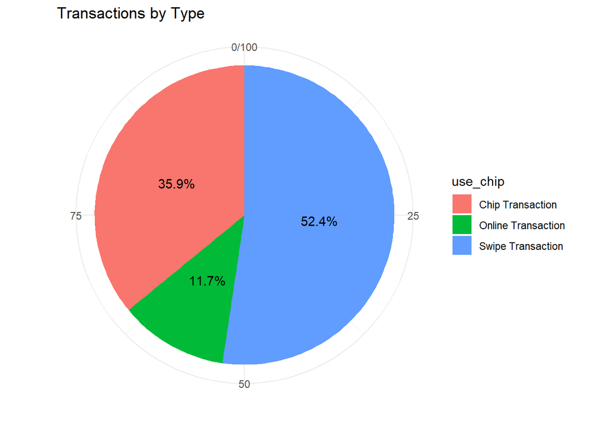

```r
#Summarizing the transactions by transaction type and converting into percentage
transaction_type = transactions %>%
  group_by(use_chip) %>%
  summarize(count = n ())%>%
  mutate(percentage = count / sum(count) * 100)

#Creating a Pie Chart to Visualize
ggplot(transaction_type, aes(x = "", y = percentage, fill = use_chip,)) +
  geom_bar(stat = "identity", width = 1) +
  coord_polar("y") + #Converting the bar plot into pie chart
  labs(title = "Transactions by Type", x = "", y = "") +
  geom_text(aes(label = paste0(round(percentage, 1), "%")),
            position = position_stack(vjust = 0.5)) +
  theme_minimal() +
  theme(legend.position = "right")
```

Transactions Count By Top Cities

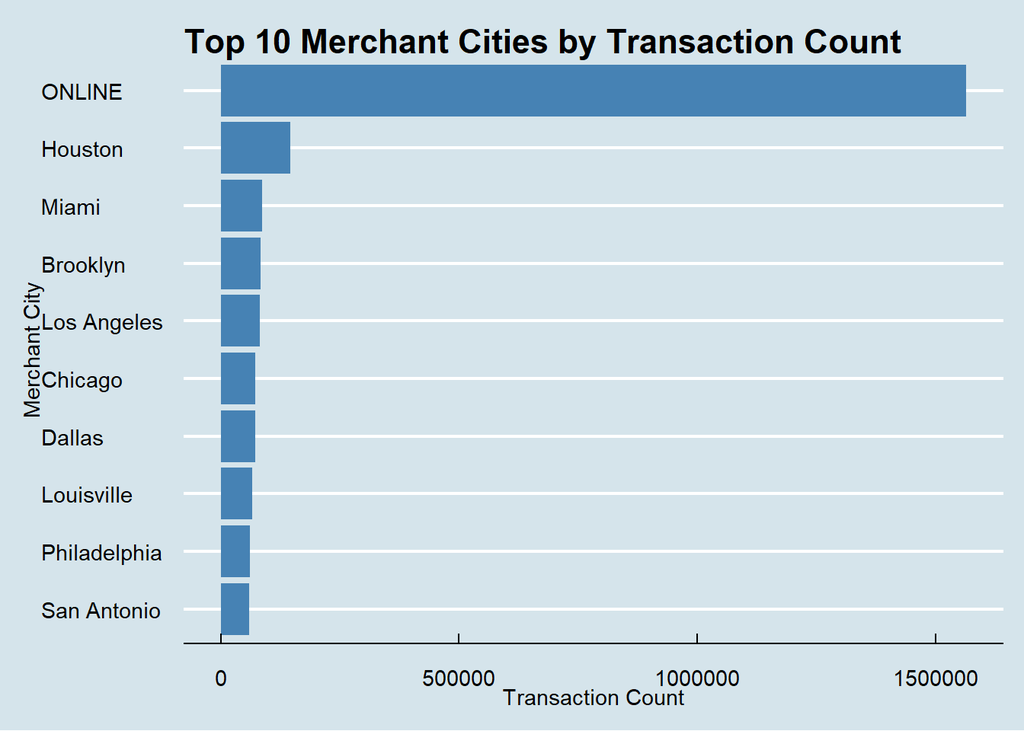

```r
#Summarizing the transactions count by merchant city and selecting the top 10 cities
top_cities = transactions %>%
  group_by(merchant_city) %>%
  summarize(transaction_count = n()) %>%
  arrange(desc(transaction_count)) %>%
  slice_head(n = 10)

#Creating a Bar plot to visualize
ggplot(top_cities, aes(x = reorder(merchant_city, transaction_count), y = transaction_count)) +
  geom_bar(stat = "identity", fill = "steelblue") +
  coord_flip() +
  labs(title = "Top 10 Merchant Cities by Transaction Count", x = "Merchant City", y = "Transaction Count") +
  theme_economist()
```

Transactions By Business Type

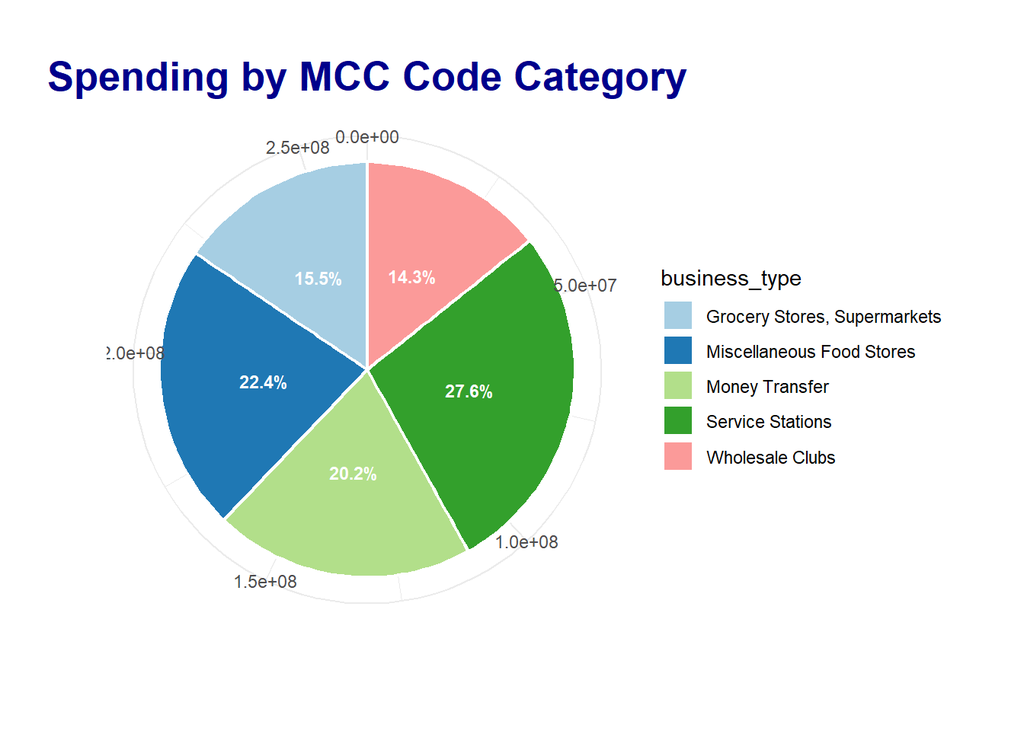

```r
#Summarizing the total transaction amount by business type and selecting the top 5 business categories
spending_category = data3 %>%
  group_by(business_type) %>%
  summarize(total_amount = sum(amount, na.rm = TRUE)) %>%
  arrange(desc(total_amount))%>%
  slice_max(total_amount, n = 5) %>%
  mutate(percentage = total_amount / sum(total_amount) * 100) #Calculating the percentage of each business type

ggplot(spending_category, aes(x = "", y = total_amount, fill = business_type)) +
  geom_bar(stat = "identity", width = 1, color = "white", size = 0.8) +  # White borders around each slice
  coord_polar("y") +  # Convert bar chart to pie chart
  labs(title = "Spending by MCC Code Category", x = "", y = "") +  # Title and remove axis labels
  geom_text(aes(label = paste0(round(percentage, 1), "%")),
            position = position_stack(vjust = 0.5),  # Position percentage labels in the center
            color = "white", size = 3, fontface = "bold") +  # White bold text for readability
  scale_fill_brewer(palette = "Paired") +  # Use the Paired color palette
  theme_minimal() +  # Remove gridlines and background
  theme(
    legend.position = "right",  # Position legend to the right
    plot.title = element_text(size = 20, face = "bold", color = "darkblue", hjust = 0.5),  # Fancy title
    plot.margin = margin(30, 30, 30, 30)  # Add padding around the plot
  )
```

Average Spending By Income Bracket and Linear Regression between Yearly Income and Transaction Amount

```r
avg_spending = data3 %>%
  group_by(income_bin) %>%
  summarize(average_spending = mean(amount, na.rm = TRUE))

print(avg_spending)
```

```
## # A tibble: 4 × 2
##   income_bin   average_spending
##   <fct>                   <dbl>
## 1 Low                      40.0
## 2 Middle                   51.9
## 3 Upper Middle             70.8
## 4 High                     84.2
```

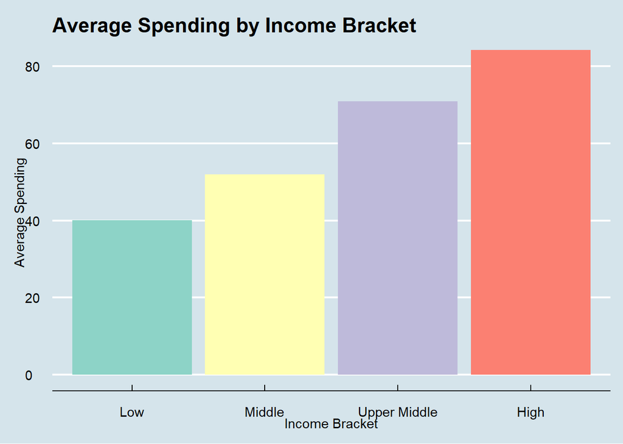

```r
ggplot(avg_spending, aes(x = income_bin, y = average_spending, fill = income_bin)) +
  geom_bar(stat = "identity", show.legend = FALSE) +
  labs(
    title = "Average Spending by Income Bracket",
    x = "Income Bracket",
    y = "Average Spending"
  ) +
  theme_economist() +
  scale_fill_brewer(palette = "Set3")
```

```r
#Linear regression to assess the relationship between yearly income and spending
lm_model <- lm(amount ~ yearly_income, data = sampled_data)
summary(lm_model)
```

```
##
## Call:
## lm(formula = amount ~ yearly_income, data = sampled_data)
##
## Residuals:
##    Min     1Q Median     3Q    Max
## -139.8  -39.8  -16.3   19.6 6690.5
##
## Coefficients:
##                Estimate Std. Error t value Pr(>|t|)
## (Intercept)   3.422e+01  1.378e-01   248.3   <2e-16 ***
## yearly_income 3.819e-04  2.641e-06   144.6   <2e-16 ***
## ---
## Signif. codes:  0 '***' 0.001 '**' 0.01 '*' 0.05 '.' 0.1 ' ' 1
##
## Residual standard error: 72.01 on 1299997 degrees of freedom
## Multiple R-squared:  0.01584,    Adjusted R-squared:  0.01584
## F-statistic: 2.092e+04 on 1 and 1299997 DF,  p-value: < 2.2e-16
```

```r
# Print the model's coefficients
print(coef(lm_model))
```

```
##   (Intercept) yearly_income
##  3.422005e+01  3.819437e-04
```

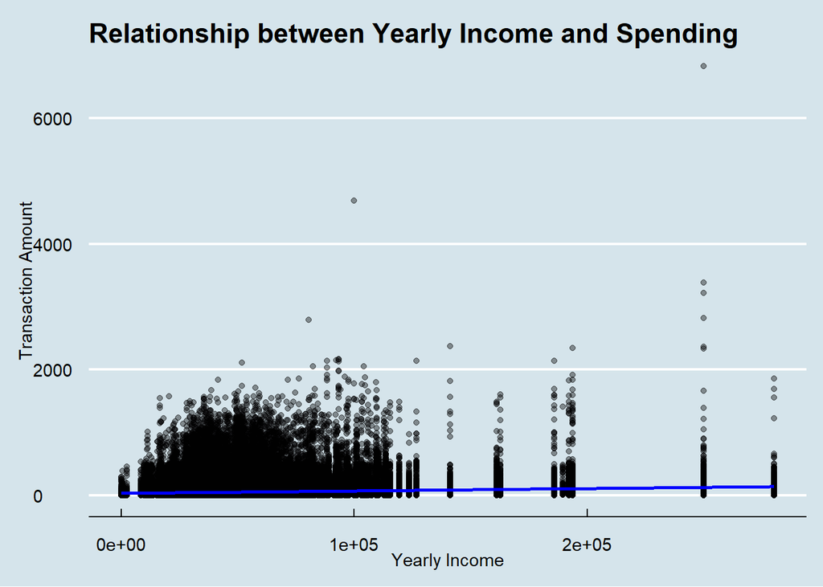

```r
# Plotting the linear regression between yearly income and transaction amount
ggplot(sampled_data, aes(x = yearly_income, y = amount)) +
  geom_point(alpha = 0.4) +  # Scatter plot of the data points
  geom_smooth(method = "lm", color = "blue", se = FALSE) +  # Adding the regression line
  labs(
    title = "Relationship between Yearly Income and Spending",
    x = "Yearly Income",
    y = "Transaction Amount"
  ) +
  theme_economist()
```

Average Spending By Credit Score and Linear Regression Between Credit Score and Transaction Amount

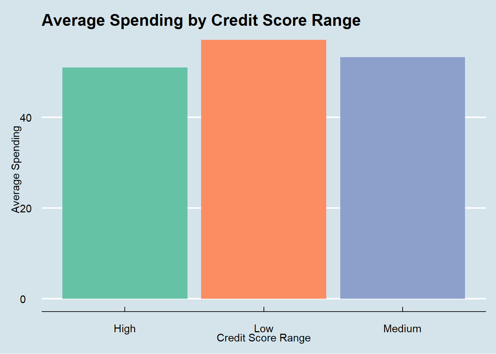

```r
avg_spending_by_CreditScore = data3 %>%
  group_by(credit_score_range) %>%
  summarize(average_spending = mean(amount, na.rm = TRUE))

ggplot(avg_spending_by_CreditScore, aes(x = credit_score_range, y = average_spending, fill = credit_score_range)) +
  geom_bar(stat = "identity", show.legend = FALSE) +
  labs(
    title = "Average Spending by Credit Score Range",
    x = "Credit Score Range",
    y = "Average Spending"
  ) +
  theme_economist() +
  scale_fill_brewer(palette = "Set2")
```

```r
#Linear regression to assess the relationship between credit score and spending amount
lm_credit_score = lm(amount~credit_score, data = sampled_data)
summary(lm_credit_score)
```

```
##
## Call:
## lm(formula = amount ~ credit_score, data = sampled_data)
##
## Residuals:
##    Min     1Q Median     3Q    Max
##  -58.8  -41.2  -17.4   20.0 6768.5
##
## Coefficients:
##                Estimate Std. Error t value Pr(>|t|)
## (Intercept)  73.9707518  0.7012497  105.48   <2e-16 ***
## credit_score -0.0308399  0.0009774  -31.55   <2e-16 ***
## ---
## Signif. codes:  0 '***' 0.001 '**' 0.01 '*' 0.05 '.' 0.1 ' ' 1
##
## Residual standard error: 72.56 on 1299997 degrees of freedom
## Multiple R-squared:  0.0007653,  Adjusted R-squared:  0.0007645
## F-statistic: 995.7 on 1 and 1299997 DF,  p-value: < 2.2e-16
```

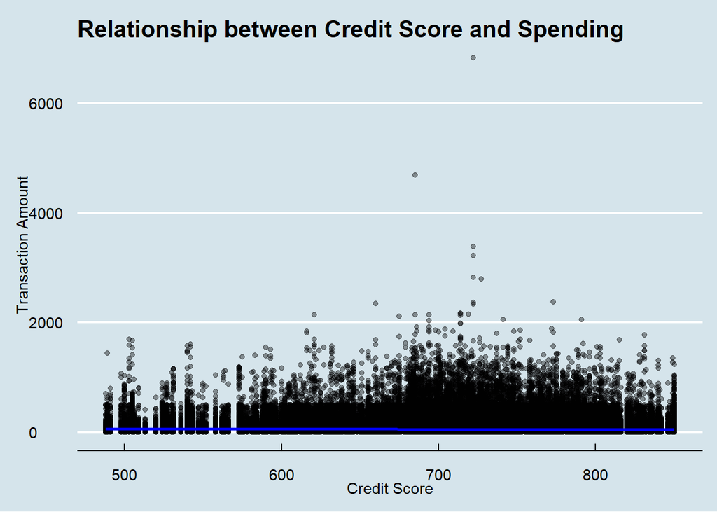

```r
# Plotting the linear regression between Credit Score and transaction amount
ggplot(sampled_data, aes(x = credit_score, y = amount)) +
  geom_point(alpha = 0.4) +  # Scatter plot of the data points
  geom_smooth(method = "lm", color = "blue", se = FALSE) +  # Adding the regression line
  labs(
    title = "Relationship between Credit Score and Spending",
    x = "Credit Score",
    y = "Transaction Amount"
  ) +
  theme_economist()
```

Average Spending By Age and Linear Regression between Current Age and Transaction Amount

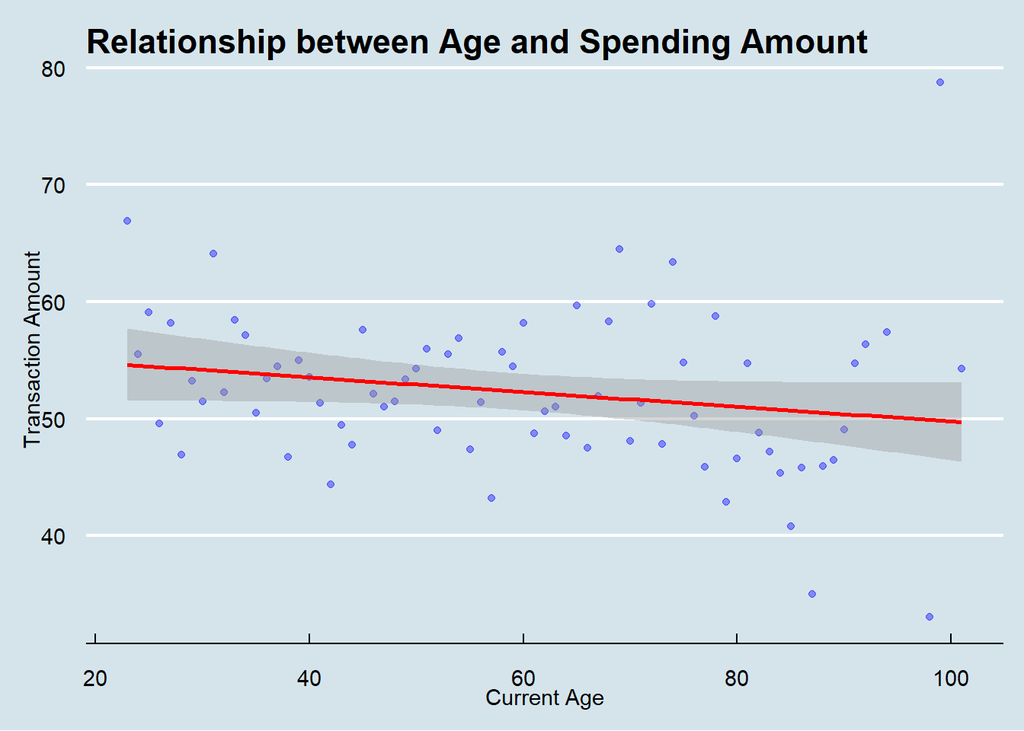

```r
avg_spending_by_age = data3 %>%
  group_by(current_age) %>%
  summarize(average_spending = mean(amount, na.rm = TRUE))

ggplot(avg_spending_by_age, aes(x = current_age, y = average_spending))+
 geom_point(alpha = 0.4, color = "blue") + # Scatter points
  geom_smooth(method = "lm", color = "red") + # Regression line
  labs(
    title = "Relationship between Age and Spending Amount",
    x = "Current Age",
    y = "Transaction Amount"
  ) +
  theme_economist()
```

```r
#Linear regression to assess the relationship between current age and spending amount
lm_age_spending = lm(amount ~ current_age, data = sampled_data)
summary(lm_age_spending)
```

```
##
## Call:
## lm(formula = amount ~ current_age, data = sampled_data)
##
## Residuals:
##    Min     1Q Median     3Q    Max
##  -53.5  -41.4  -17.4   20.0 6768.8
##
## Coefficients:
##              Estimate Std. Error t value Pr(>|t|)
## (Intercept) 54.895581   0.227464  241.34   <2e-16 ***
## current_age -0.054850   0.004045  -13.56   <2e-16 ***
## ---
## Signif. codes:  0 '***' 0.001 '**' 0.01 '*' 0.05 '.' 0.1 ' ' 1
##
## Residual standard error: 72.58 on 1299997 degrees of freedom
## Multiple R-squared:  0.0001414,  Adjusted R-squared:  0.0001406
## F-statistic: 183.8 on 1 and 1299997 DF,  p-value: < 2.2e-16
```

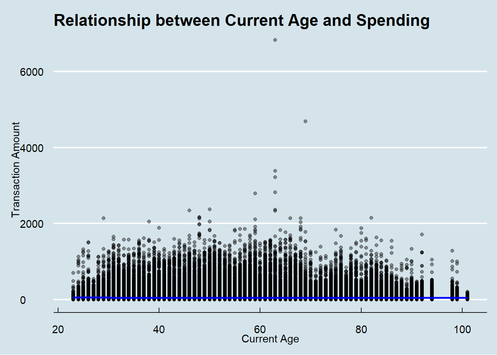

```r
# Plotting the linear regression between Current Age and Transaction Amount
ggplot(sampled_data, aes(x = current_age, y = amount)) +
  geom_point(alpha = 0.4) +  # Scatter plot of the data points
  geom_smooth(method = "lm", color = "blue", se = FALSE) +  # Adding the regression line
  labs(
    title = "Relationship between Current Age and Spending",
    x = "Current Age",
    y = "Transaction Amount"
  ) +
  theme_economist()
```

Average Debt and Age and Linear Regression Between Total Debt and Age

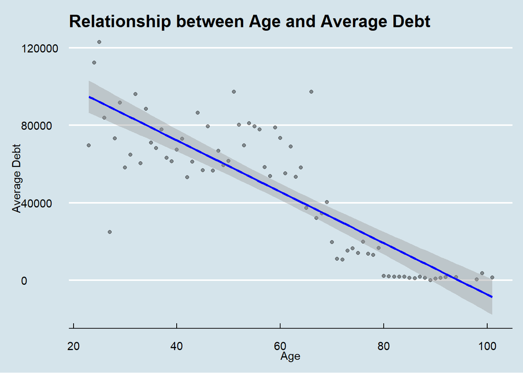

```r
avg_debt_by_age = data3 %>%
  group_by(current_age) %>%
  summarize(average_debt = mean(total_debt, na.rm = TRUE))

# Plotting the relationship
ggplot(avg_debt_by_age, aes(x = current_age, y = average_debt)) +
  geom_point(alpha = 0.4) +
  geom_smooth(method = "lm", color = "blue") +
  labs(
    title = "Relationship between Age and Average Debt",
    x = "Age",
    y = "Average Debt"
  ) +
  theme_economist()
```

```r
#Linear regression to assess the relationship between current age and total debt
lm_age_debt <- lm(total_debt ~ current_age, data = user_data)
summary(lm_age_debt)
```

```
##
## Call:
## lm(formula = total_debt ~ current_age, data = user_data)
##
## Residuals:
##    Min     1Q Median     3Q    Max
## -88229 -29732  -9850  22200 432510
##
## Coefficients:
##              Estimate Std. Error t value Pr(>|t|)
## (Intercept) 104341.69    2950.93   35.36   <2e-16 ***
## current_age   -895.15      60.24  -14.86   <2e-16 ***
## ---
## Signif. codes:  0 '***' 0.001 '**' 0.01 '*' 0.05 '.' 0.1 ' ' 1
##
## Residual standard error: 49600 on 1998 degrees of freedom
## Multiple R-squared:  0.0995, Adjusted R-squared:  0.09905
## F-statistic: 220.8 on 1 and 1998 DF,  p-value: < 2.2e-16
```

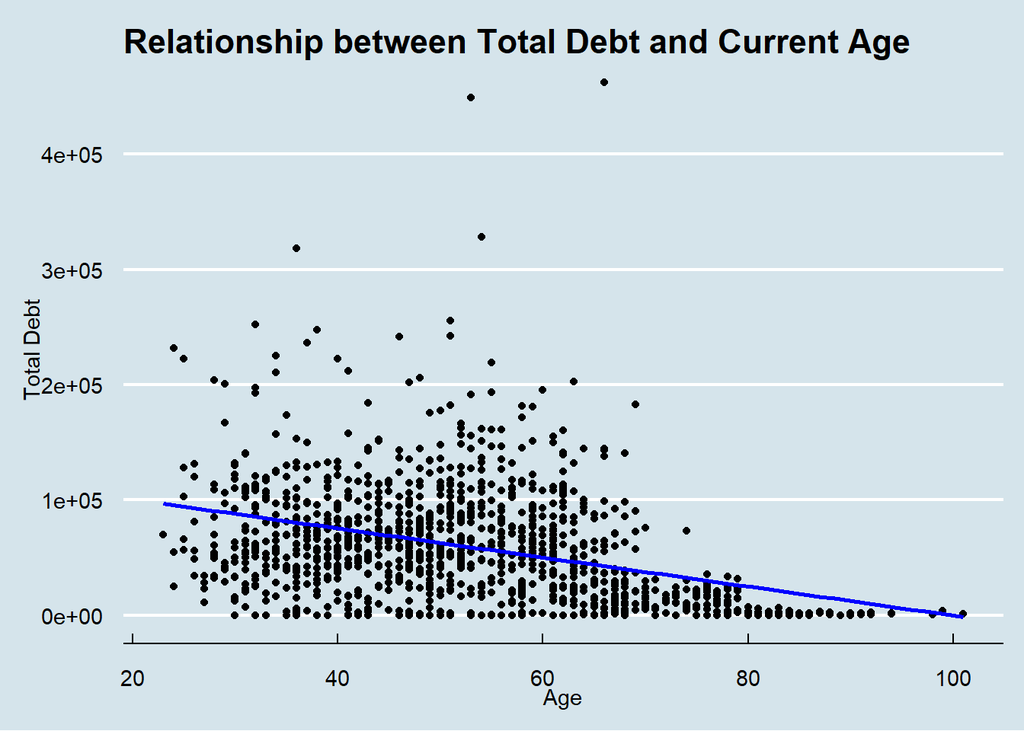

```r
# Plotting the linear regression between Current Age and Total Debt
ggplot(sampled_data, aes(x = current_age, y = total_debt)) +
  geom_point(alpha = 0.4) +  # Scatter plot of the data points
  geom_smooth(method = "lm", color = "blue", se = FALSE) +  # Adding the regression line
  labs(
    title = "Relationship between Total Debt and Current Age",
    x = "Age",
    y = "Total Debt"
  ) +
  theme_economist()
```

Multiple Linear Regression Predicting Transaction Amount Based on Current Age, Credit Score, and Yearly Income

```r
lm_multiple <- lm(amount ~ current_age + credit_score + yearly_income, data = sampled_data)
summary(lm_multiple)
```

```
##
## Call:
## lm(formula = amount ~ current_age + credit_score + yearly_income,
##     data = sampled_data)
##
## Residuals:
##    Min     1Q Median     3Q    Max
## -138.4  -39.8  -16.3   19.6 6691.0
##
## Coefficients:
##                 Estimate Std. Error t value Pr(>|t|)
## (Intercept)    5.105e+01  7.570e-01  67.443  < 2e-16 ***
## current_age    1.163e-02  4.044e-03   2.876  0.00402 **
## credit_score  -2.430e-02  9.713e-04 -25.019  < 2e-16 ***
## yearly_income  3.798e-04  2.663e-06 142.641  < 2e-16 ***
## ---
## Signif. codes:  0 '***' 0.001 '**' 0.01 '*' 0.05 '.' 0.1 ' ' 1
##
## Residual standard error: 71.99 on 1299995 degrees of freedom
## Multiple R-squared:  0.01632,    Adjusted R-squared:  0.01632
## F-statistic:  7189 on 3 and 1299995 DF,  p-value: < 2.2e-16
```

Avg Debt By Age Group

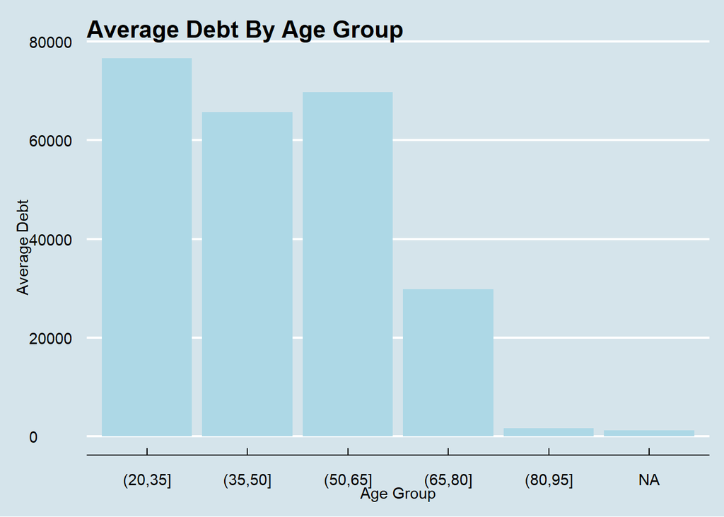

```r
#Creating Age Bins and Summarizing by Average Debt
avg_debt_and_age = data3 %>%
  mutate(age_bin = cut(current_age, breaks = seq(20,100,15))) %>%
  group_by(age_bin) %>%
  summarize(avg_debt = mean(total_debt, na.rm = TRUE))

#Plotting the Graph
ggplot(avg_debt_and_age, aes(x = age_bin, y = avg_debt)) +
  geom_bar(stat = "identity", fill = "lightblue") +
  labs(title = "Average Debt By Age Group", x = "Age Group", y = "Average Debt") +
  theme_economist()
```

Linear Regression Between Yearly Income and Total Debt

```r
#Building the linear regression model
lm_income_debt = lm(total_debt ~ yearly_income, data = user_data)
summary(lm_income_debt)
```

```
##
## Call:
## lm(formula = total_debt ~ yearly_income, data = user_data)
##
## Residuals:
##     Min      1Q  Median      3Q     Max
## -277733  -25828     586   23761  222704
##
## Coefficients:
##                Estimate Std. Error t value Pr(>|t|)
## (Intercept)   6.500e+03  2.172e+03   2.993   0.0028 **
## yearly_income 1.251e+00  4.244e-02  29.486   <2e-16 ***
## ---
## Signif. codes:  0 '***' 0.001 '**' 0.01 '*' 0.05 '.' 0.1 ' ' 1
##
## Residual standard error: 43630 on 1998 degrees of freedom
## Multiple R-squared:  0.3032, Adjusted R-squared:  0.3029
## F-statistic: 869.4 on 1 and 1998 DF,  p-value: < 2.2e-16
```

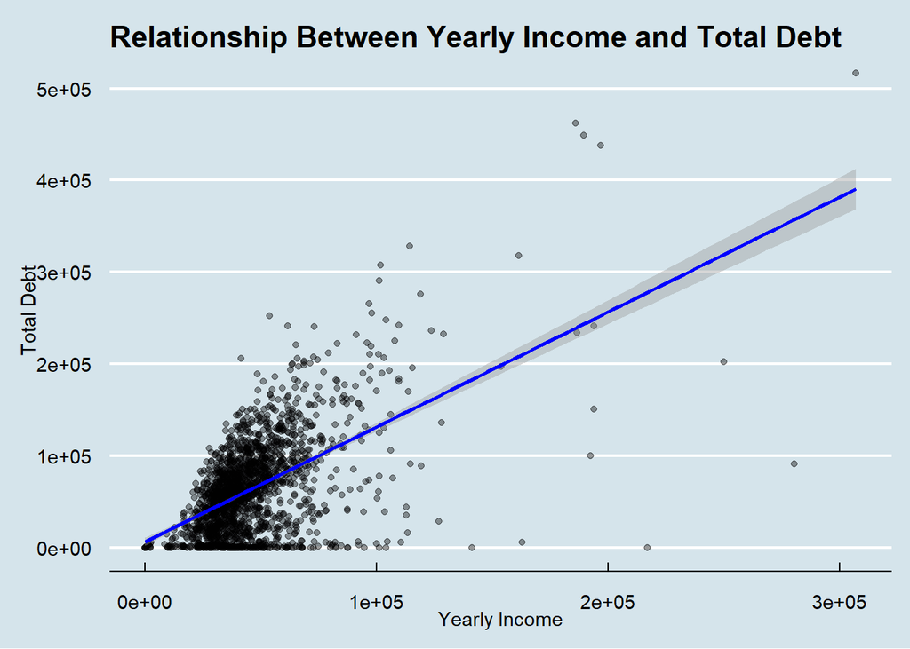

```r
#Plotting the graph
ggplot(user_data, aes(x = yearly_income, y = total_debt)) +
  geom_point(alpha = 0.4) +
  geom_smooth(method = "lm", color = "blue") +
  labs(title = "Relationship Between Yearly Income and Total Debt",
       x = "Yearly Income", y = "Total Debt") +
  theme_economist()
```

Time Series Analysis on Transaction Trends Over Time

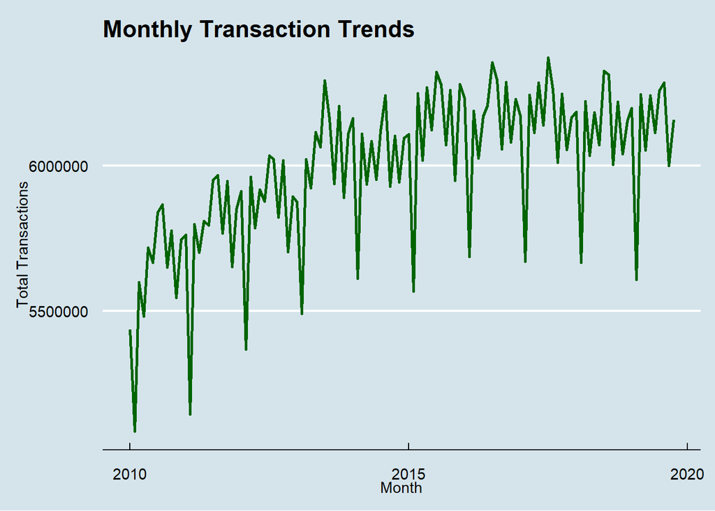

```r
ggplot(transactions1, aes(x = transaction_month, y = total_amount)) +
  geom_line(color = "darkgreen", size = 1) +
  labs(title = "Monthly Transaction Trends", x = "Month", y = "Total Transactions") +
  theme_economist()
```

Correlation Between Credit Limit and Credit Score

```r
# Calculate the correlation coefficient between credit limit and credit score
correlation <- cor(data4$credit_limit, data4$credit_score, use = "complete.obs")

# Print the correlation result
print(paste("Correlation between Credit Limit and Credit Score: ", round(correlation, 2)))
```

```
## [1] "Correlation between Credit Limit and Credit Score:  0.05"
```

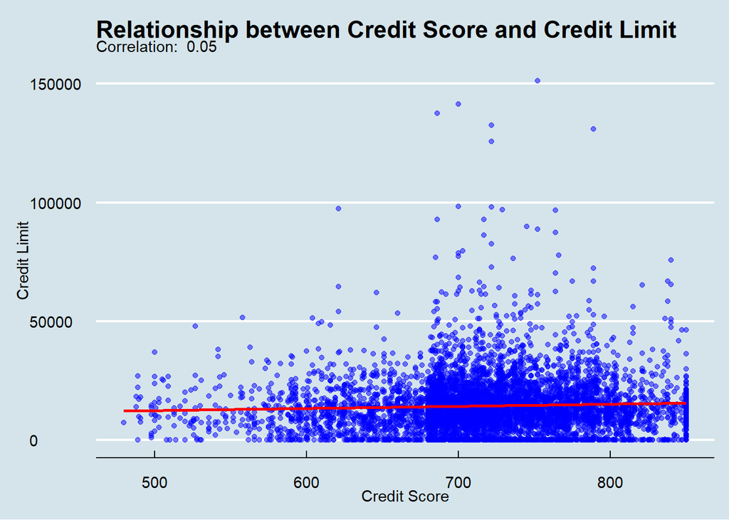

```r
# Create a scatter plot
ggplot(data4, aes(x = credit_score, y = credit_limit)) +
  geom_point(alpha = 0.5, color = "blue") +
  geom_smooth(method = "lm", color = "red", se = FALSE) +
  labs(
    title = "Relationship between Credit Score and Credit Limit",
    subtitle = paste("Correlation: ", round(correlation, 2)),
    x = "Credit Score",
    y = "Credit Limit"
  ) +
  theme_economist()
```

Correlation Between Income and Credit Limit

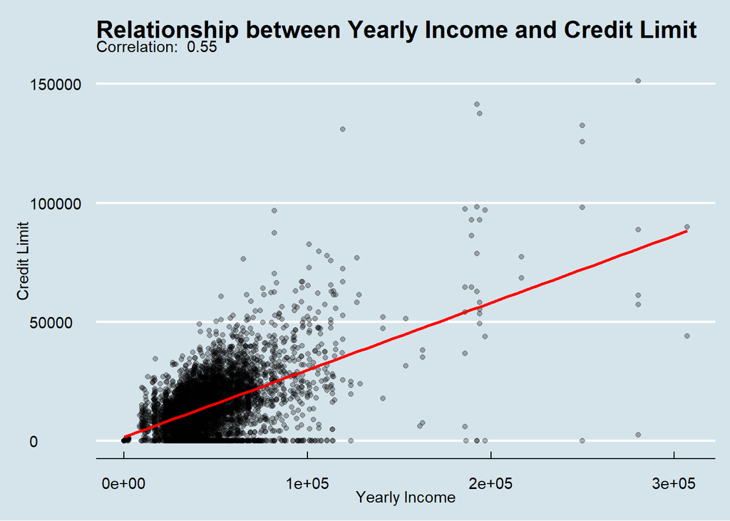

```r
# Step 1: Calculate the correlation between yearly income and credit limit
correlation_income_limit <- cor(data4$yearly_income, data4$credit_limit, use = "complete.obs")

# Step 2: Create a scatter plot
ggplot(data4, aes(x = yearly_income, y = credit_limit)) +
  geom_point(alpha = 0.3, color = "black") +
  geom_smooth(method = "lm", color = "red", se = FALSE) +
  labs(
    title = "Relationship between Yearly Income and Credit Limit",
    subtitle = paste("Correlation: ", round(correlation_income_limit, 2)),
    x = "Yearly Income",
    y = "Credit Limit"
  ) +
  theme_economist()
```

Linear Regression Between Total_debt and Number Of Credit Cards

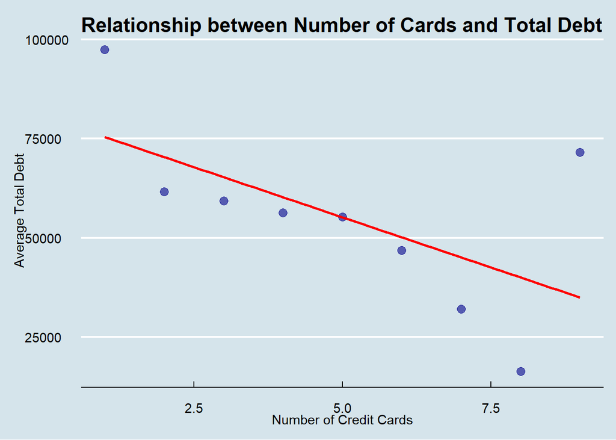

```r
# Aggregate total debt and number of credit cards
debt_by_cards <- sampled_data %>%
  group_by(num_credit_cards) %>%
  summarize(
    avg_total_debt = mean(total_debt, na.rm = TRUE)
  )

# Plot the relationship
ggplot(debt_by_cards, aes(x = num_credit_cards, y = avg_total_debt)) +
  geom_point(color = "darkblue", size = 3, alpha = 0.6) +
  geom_smooth(method = "lm", color = "red", se = FALSE) +
  labs(
    title = "Relationship between Number of Cards and Total Debt",
    x = "Number of Credit Cards",
    y = "Average Total Debt"
  ) +
  theme_economist()
```

Correlation Of Regional Income and Average Transaction Amount

```r
# Calculate average transaction amount by state
state_avg_income <- sampled_data %>%
  group_by(merchant_state) %>%
  summarize(avg_transaction = mean(amount, na.rm = TRUE),
            avg_income = mean(yearly_income, na.rm = TRUE))

print(state_avg_income)
```

```
## # A tibble: 51 × 3
##    merchant_state avg_transaction avg_income
##    <chr>                    <dbl>      <dbl>
##  1 AK                       236.      49198.
##  2 AL                        43.9     38184.
##  3 AR                        45.6     34866.
##  4 AZ                        51.6     43321.
##  5 CA                        53.2     46799.
##  6 CO                        60.9     51072.
##  7 CT                        54.3     64898.
##  8 DC                        53.3     46617.
##  9 DE                        40.2     45825.
## 10 FL                        51.0     43241.
## # ℹ 41 more rows
```

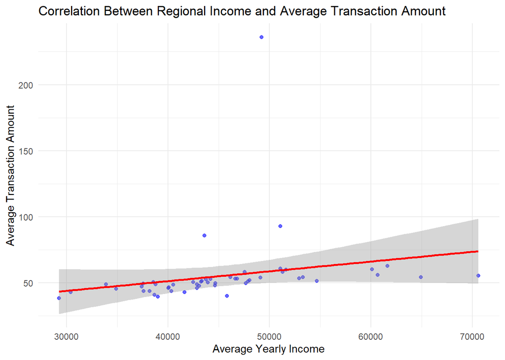

```r
# Scatterplot of average income vs. average transaction amount
ggplot(state_avg_income, aes(x = avg_income, y = avg_transaction)) +
  geom_point(color = "blue", alpha = 0.6) +
  geom_smooth(method = "lm", color = "red") +
  labs(
    title = "Correlation Between Regional Income and Average Transaction Amount",
    x = "Average Yearly Income",
    y = "Average Transaction Amount"
  ) +
  theme_minimal()
```